# yuxih_Lab04

Yuxin He

2023-11-19

### Sentiment analysis

I analyzed the album named The Search for Everything by John Mayer.

```r
library(tidytext)
library(textdata)
library(tidyverse)
get_sentiments("nrc")
```

```
## # A tibble: 13,872 × 2
##    word        sentiment
##    <chr>       <chr>
##  1 abacus      trust
##  2 abandon     fear
##  3 abandon     negative
##  4 abandon     sadness
##  5 abandoned   anger
##  6 abandoned   fear
##  7 abandoned   negative
##  8 abandoned   sadness
##  9 abandonment anger
## 10 abandonment fear
## # ℹ 13,862 more rows
```

```r
##lines <- readLines("Rosie.txt")
##lines <- readLines("Rosie.txt", warn = FALSE)
```

```r
nrc_anger <- get_sentiments("nrc") %>%
  filter(sentiment == "anger")
nrc_anger
```

```
## # A tibble: 1,245 × 2
##    word        sentiment
##    <chr>       <chr>
##  1 abandoned   anger
##  2 abandonment anger
##  3 abhor       anger
##  4 abhorrent   anger
##  5 abolish     anger
##  6 abomination anger
##  7 abuse       anger
##  8 accursed    anger
##  9 accusation  anger
## 10 accused     anger
## # ℹ 1,235 more rows
```

```r
txt_directory <- "D:/桌面/648/Repo/Lab/04/Lab4prj"
file_paths <- list.files(txt_directory, pattern = "\\.txt$", full.names = TRUE)
afinn = get_sentiments("afinn")##loading the afinn sentiment lexicon included in the tidytext package

lyrics_list <- lapply(file_paths, function(file_path)##using the lapply function to apply a function to each text file in the directory
  {
  lines <- readLines(file_path, warn = FALSE)
  song_title <- lines[1]
  lyrics <- lines[-1]
  tibble(song_title = song_title, lyrics = lyrics)
})

TheSearchForEverything<- bind_rows(lyrics_list)

TheSearchForEverything <- TheSearchForEverything %>%
  filter(lyrics != "" & !is.na(lyrics))

TheSearchForEverything <- TheSearchForEverything %>%
  mutate(line_id = row_number()) %>%
  group_by(song_title) %>%
  mutate(line_number = row_number()) %>%
  ungroup()
```

```r
library(tidyverse)
library(tidytext)

tidy_song <- TheSearchForEverything


# Print or further process the resulting tidy_song data frame
print(tidy_song)
```

```
## # A tibble: 393 × 4
##    song_title lyrics                                  line_id line_number
##    <chr>      <chr>                                     <int>       <int>
##  1 Changing   I am not done changing                        1           1
##  2 Changing   Out on the run, changing                      2           2
##  3 Changing   I may be old and I may be young               3           3
##  4 Changing   But I am not done changing                    4           4
##  5 Changing   I met me someone changing                     5           5
##  6 Changing   We had some fun changing                      6           6
##  7 Changing   Sometimes I wonder if she'll be the one       7           7
##  8 Changing   When I am done changing                       8           8
##  9 Changing   Some of us stopped running                    9           9
## 10 Changing   Some of us went home                         10          10
## # ℹ 383 more rows
```

```r
library(stringr)
tidy_song <- tidy_song %>%
unnest_tokens(word,lyrics)
```

```r
library(tidyverse)
library(tidytext)

song_sentiment <- tidy_song %>%
  inner_join(get_sentiments("nrc")) %>%
  count(song_title, index = line_number, sentiment) %>%
  spread(sentiment, n, fill = 0) %>%
  mutate(sentiment = positive - negative)
```

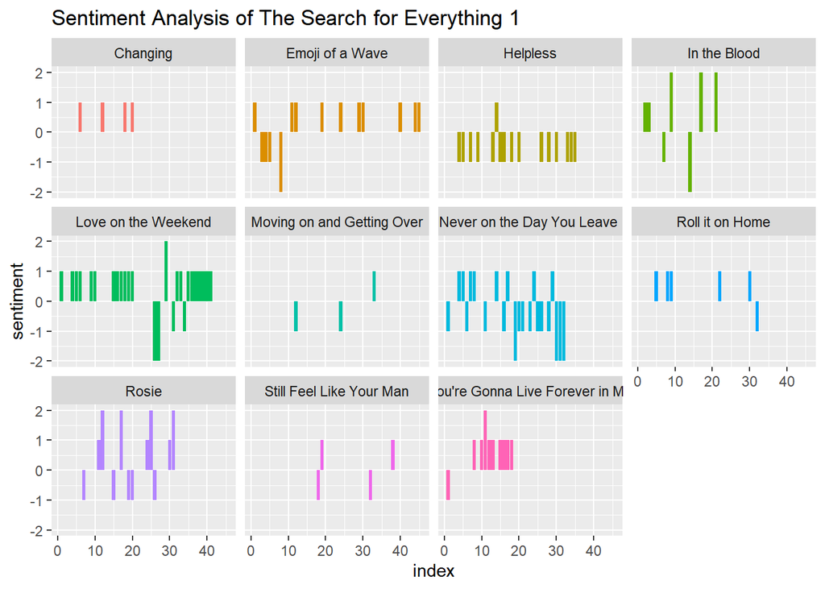

```r
ggplot(song_sentiment, aes(index, sentiment, fill = song_title)) +
  geom_col(show.legend = FALSE) +
  facet_wrap(~song_title) +
  ggtitle("Sentiment Analysis of The Search for Everything 1")
```

### Evaluating common positive and negative words

```r
nrc_word_counts <- tidy_song %>%
  inner_join(get_sentiments("nrc")) %>%
  count(word, sentiment, sort = TRUE) %>%
  ungroup()
nrc_word_counts
```

```
## # A tibble: 228 × 3
##    word     sentiment        n
##    <chr>    <chr>        <int>
##  1 love     joy             33
##  2 love     positive        33
##  3 leave    negative        16
##  4 leave    sadness         16
##  5 leave    surprise        16
##  6 helpless fear            12
##  7 helpless negative        12
##  8 helpless sadness         12
##  9 honey    positive         9
## 10 time     anticipation     8
## # ℹ 218 more rows
```

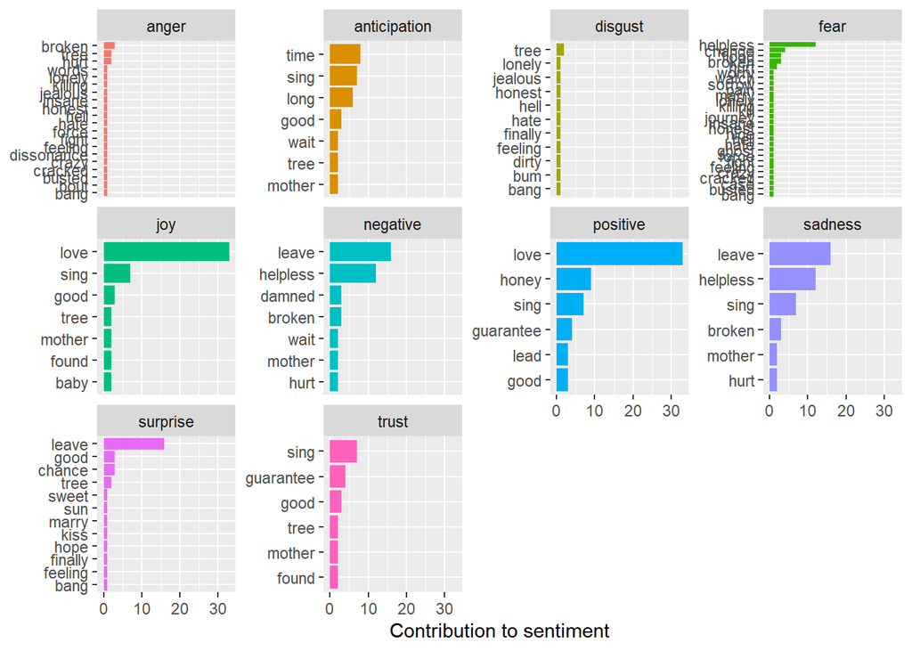

```r
nrc_word_counts %>%
  group_by(sentiment) %>%
  top_n(6) %>%
  ungroup() %>%
  mutate(word = reorder(word, n)) %>%
  ggplot(aes(word, n, fill = sentiment)) +
  geom_col(show.legend = FALSE) +
  facet_wrap(~sentiment, scales = "free_y") +
  labs(y = "Contribution to sentiment",
       x = NULL) +
  coord_flip()
```

### Word Clouds

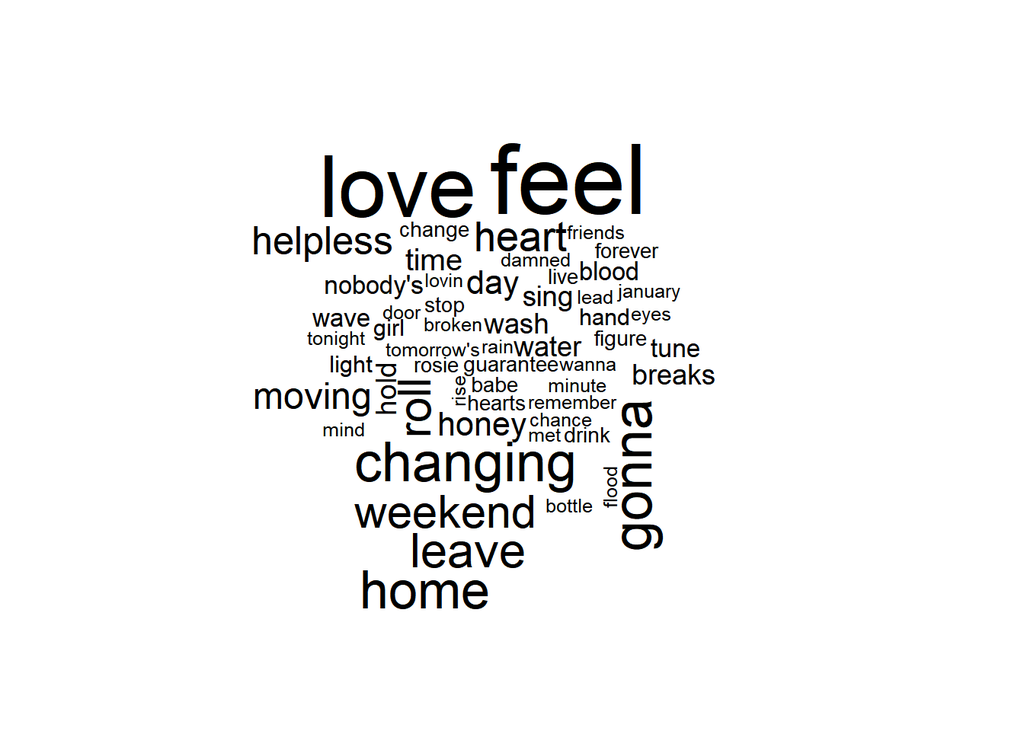

```r
library(wordcloud)
library(RColorBrewer)
tidy_song %>%
  anti_join(stop_words) %>%
  count(word) %>%
  with(wordcloud(word, n, max.words = 100))
```

```r
library(tidyverse)
library(tidytext)
library(tm)
```

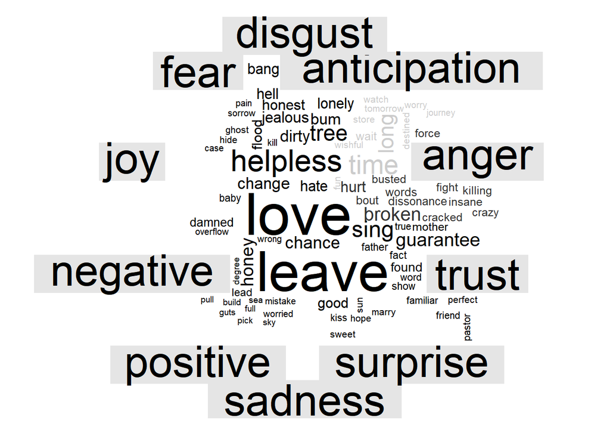

```r
library(wordcloud)

library(magrittr)
library(reshape2)
library(tm)
tidy_song %>%
  inner_join(get_sentiments("nrc")) %>%
  count(word, sentiment, sort = TRUE) %>%
  acast(word ~ sentiment, value.var = "n", fill = 0) %>%
  comparison.cloud(colors = c("gray20", "gray80"),
                   max.words = 100)
```

### Contextaulizing sentiment beyond just words

```r
library(sentimentr)
song_sentiment_sent <- TheSearchForEverything %>%
    get_sentences() %>%
    sentiment_by(by = c('song_title', 'line_number'))%>%
  as.data.frame()
```

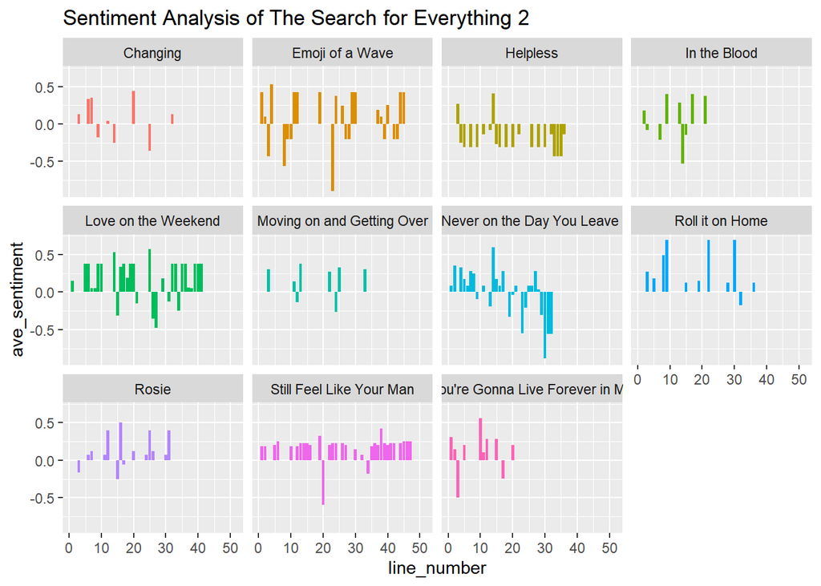

```r
ggplot(song_sentiment_sent, aes(line_number, ave_sentiment, fill = song_title)) +
  geom_col(show.legend = FALSE) +
  facet_wrap(~song_title) +
  ggtitle("Sentiment Analysis of The Search for Everything 2")
```

### Answers:

1.I used “nrc” to analyze the album sentiment.I analyzed the album named The Search for Everything by John Mayer. There are 10 kinds of emotions in this album. Two of them are negative and positive.

According to the plot “Sentiment Analysis of the Search for Everything 1”, we can see there are not a lot negative or positive words in the songs “Moving on and Getting Over”, “Still Feel Like Your Man” and “Roll it on Home”. The lyrics in “Emoji of a Wave”, “In the Blood”, “Love on the Weekend”, “Rosie”, and “You’re Gonna Live Forever in Me” are more positive. And the sentiment of “Helpless” and “Never on the Day You Leave” is more negative.

2.Analyzing language can be complex due to some personal feelings, opinions, and biases. For example, the tone can affect the sentiment of one sentence but it is hard be recognized sometimes.